# Regresja liniowa

## Regresja liniowa

- **Regresja** to metoda pozwalająca ocenić zależność pomiędzy dwiema lub więcej zmiennymi;
- **Regresja liniowa** to metoda starająca sie opisać tą zalezność za pomocą linii prostej.

## Regresja liniowa

- Regresja liniowa wyznacza linię (prostą), która obrazuje wplyw zmiennej objaśniającej na zmienną objaśnianą
- Ta zależność jest opisywana za pomoca równania liniowego:

**y = ax + b**, gdzie

**y** to zmienna objaśniana,  
**x** to zmienna objaśniająca,  
**a** to nachylenie linii,  
**b** to punkt przecięcia z OY.

## Parametry równania liniowego

https://www.desmos.com/calculator

## Regresja liniowa w R

- Funkcja w R, ktora umożliwia oszacowanie parametrów modelu liniowego to **lm** (Linear Model)

## Prosty przykład

```r
# tworzymy dwie zmienne
y <- c(9.5, 8.2, 4.9, 6.7, 12.9, 14.1, 5.6, 8.0, 12.6, 7.2)
x <- c(4.5, 3.7, 1.8, 1.3, 3.2, 3.8, 2.5, 4.5, 4.1, 1.1)

# objaśniamy zmienną y za pomocą zmiennej x
fit <- lm(y~x)
fit
```

```
##
## Call:
## lm(formula = y ~ x)
##
## Coefficients:
## (Intercept)            x
##       4.616        1.427
```

```r
# Punkt przeciecia z osia OY 4.616, nachylenie to 1.427
```

## Wykres

- Wykres pozwalający zobrazować zależność pomiędzy zmienną objaśnianą **y**, a objaśniającą **x** to tzw. **wykres rozrzutu**

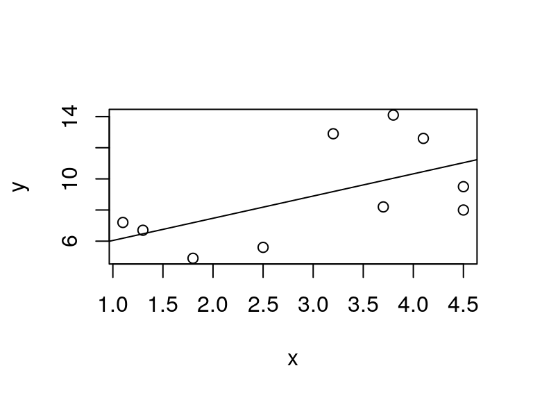

```r
plot(y~x)
# dodajemy linię regresji
abline(fit)
```

## Cwiczenie 1:

Importujemy dane cars.csv  
http://pluto.huji.ac.il/~msby/StatThink/Datasets/cars.csv

```r
library(readr)
cars <- read_csv("~/googledrive/UAM/Stat/cw/cars.csv")
```

## Cwiczenie 1:

Dopasujmy linię regresji do zależności pomiędzy pojemnością silnika (engine.size) a jego mocą (horsepower).

```r
fit.power <- lm(horsepower ~ engine.size, data=cars)
fit.power
```

```
##
## Call:
## lm(formula = horsepower ~ engine.size, data = cars)
##
## Coefficients:
## (Intercept)  engine.size
##      6.6414       0.7695
```

## Ćwiczenie 1

Wykres rozrzutu dla zmiennych “konie mechaniczne” vs. “pojemność silnika”"

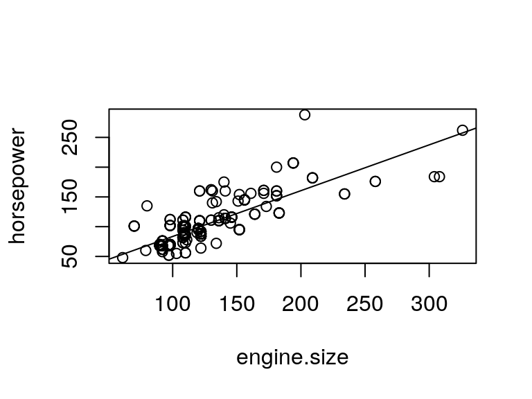

```r
plot(horsepower ~ engine.size, data=cars)
# linia regresji
abline(fit.power)
```

## Interpretacja modelu regresji

```r
options(scipen=999) # wyłączam zapis naukowy
summary(fit.power)
```

[output not shown]

## Interpretacja modelu regresji:

### **Wartość p**

H0: wartość szacowanego parametru wynosi 0 (jest on nieistotny)

H1: wartość szacowanego parametru jest różna od 0 (jest on istotny)

Jeżeli wartość p > 0.05 to nie ma podstaw do odrzucenia H0

Jeżeli wartość p < 0.05 odrzucamy H0 i przyjmujemy H1

## Interpretacja modelu regresji:

### **Przedziały ufności dla parametrów**

```r
confint(fit.power)
```

```
##                  2.5 %     97.5 %
## (Intercept) -3.6775989 16.9603564
## engine.size  0.6922181  0.8467537
```

## Składnik resztowy rownania regresji

```r
residuals(fit.power)
```

[output not shown]

[output cut: 13 more lines]

[output not shown]

## Składnik resztowy rownania regresji

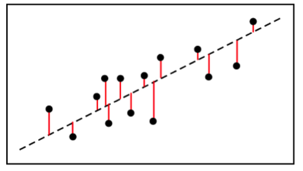

## Wskaźnik R2

- Tzw. “wskaźnik dopasowania modelu”
- Im bliżej punkty leżą linii regresji, tym wartosc R2 wyższa
- Im mniejszy trend zauwazalny w danych, tym wartosc R2 blizsza 0

## Ćwiczenie 2:

Zbadajmy zależność pomiędzy moca silnika “horse.power” a długością samochodu “length”

## Ćwiczenie 2:

```r
summary(lm(horsepower ~ length, data=cars))
```

## Ćwiczenie 2:

```
##
## Call:
## lm(formula = horsepower ~ length, data = cars)
##
## Residuals:
##    Min     1Q Median     3Q    Max
## -53.57 -20.35  -6.69  14.45 180.72
##
## Coefficients:
##              Estimate Std. Error t value Pr(>|t|)
## (Intercept) -205.3971    32.8185  -6.259  2.3e-09 ***
## length         1.7796     0.1881   9.459  < 2e-16 ***
## ---
## Signif. codes:  0 '***' 0.001 '**' 0.01 '*' 0.05 '.' 0.1 ' ' 1
##
## Residual standard error: 33.12 on 201 degrees of freedom
##   (2 observations deleted due to missingness)
## Multiple R-squared:  0.308,  Adjusted R-squared:  0.3046
## F-statistic: 89.47 on 1 and 201 DF,  p-value: < 2.2e-16
```

## Ćwiczenie 2

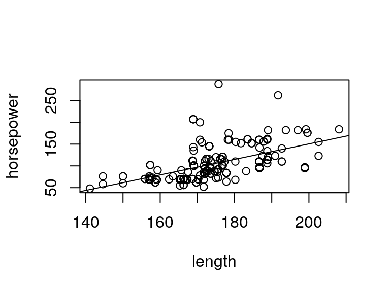

```r
# wykres rozrzutu
plot(horsepower ~ length, data=cars)
# dodajemy linie regresji
abline(lm(horsepower ~ length, data=cars))
```

## Wybór modelu

Który model bedzie lepszy dla objaśnienie “mocy silnika”?

**moc silnika ~ długość samochodu**

**moc silnika ~ pojemność silnika**

*Dlaczego?*